# Monday 09:15–10:00: Isotope Models for Ecology

## General pattern for this course

- 09:15 - 10:00 Lecture
- 10:00 - 10:45 Discussion
- 10:45 - 11:30 Lecture
- 11:30 - 12:00 Discussion
- 12:00 - 12:45 Lecture
- 12:45 - 14:00 Lunch
- 14:00 - 15:30 Practical
- 15:30 - 16:00 Break
- 16:00 - 17:30 Discussion

## Questions ecologists often ask

- What is this animal eating?
- Are these animals specialists or generalists?
- Why are these populations of animals eating different things?
- How is this community functioning?

## Isotopes can provide insights

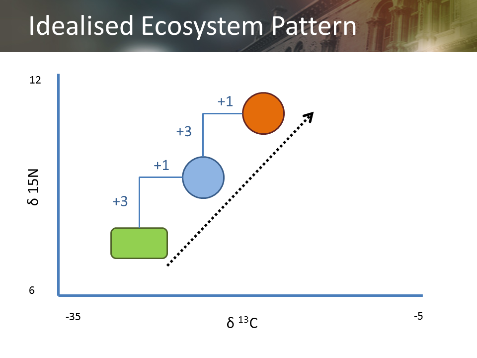

## Moving heavy isotopes is hard work

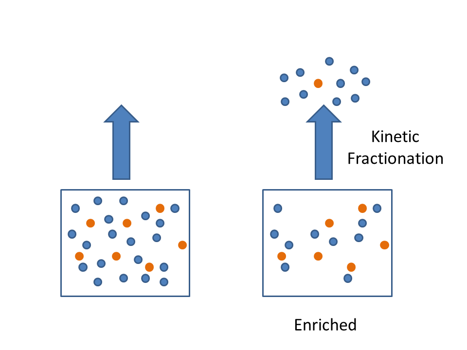

## Heavy isotopes are chemically sticky

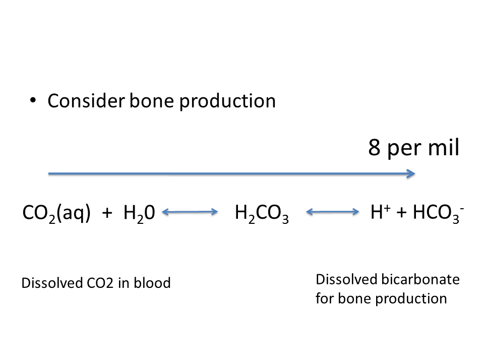

## Observe the states and infer the process

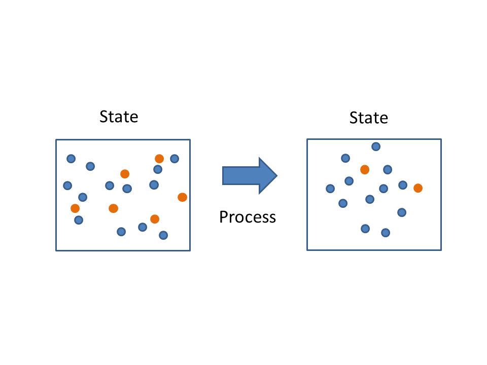

## Ecological process inferred by isotopes

- Newsome, Martinez del Rio, Bearhop & Phillips. 2007. A Niche for Isotopic Ecology. Frontiers in Ecology and the Environment.
- d-space and p-space

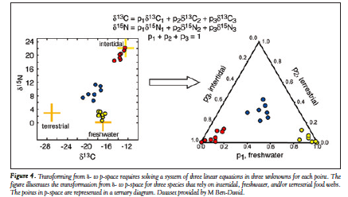

## Mixing Models move from d- to p-space

- Direct measure of trophic interactions via consumption

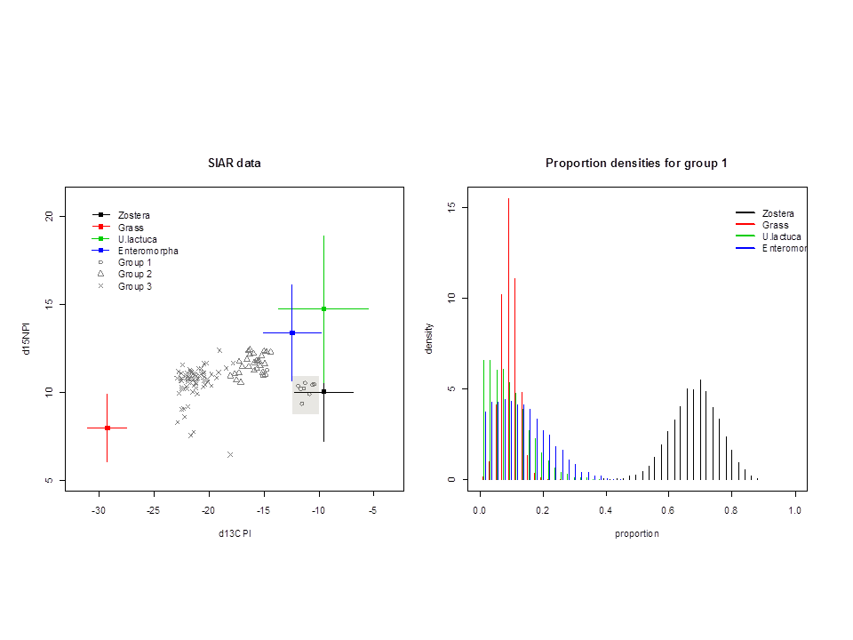

## Determined system - 2 sources 1 tracer

- How much of black and blue is the red dot made of?
- `consumer = (1/3)*(-10) + (2/3)*(5) = 0`

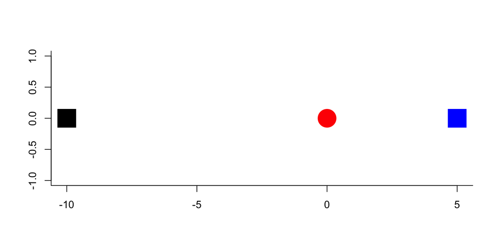

## Determined system - 3 sources 2 tracers

- How much of black, blue and magenta is the red dot made of?
- `p = c(0.2, 0.4, 0.4)`

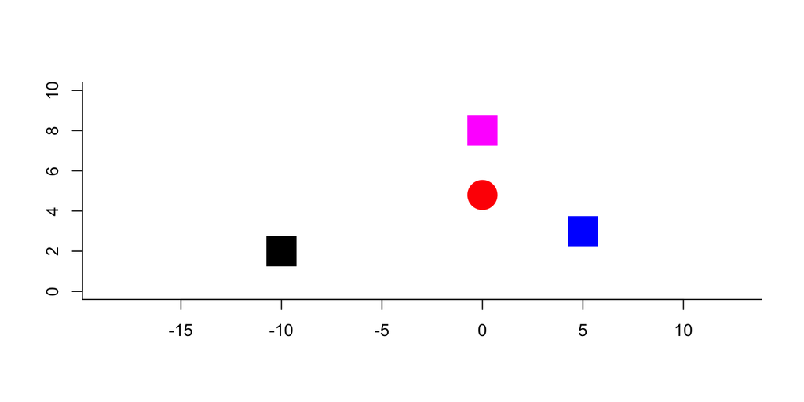

## Under-determined - 3 sources 1 tracers

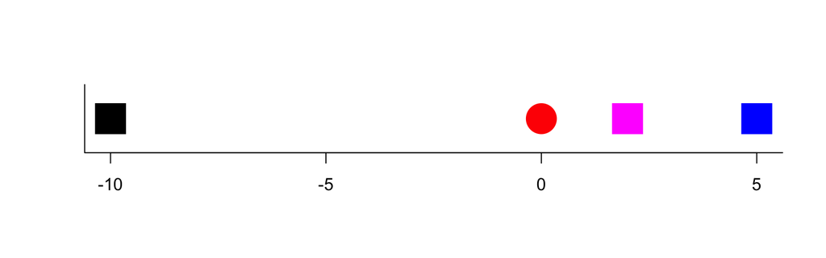

## Under-determined - 4 sources 2 tracers

- similar issue but more nuanced

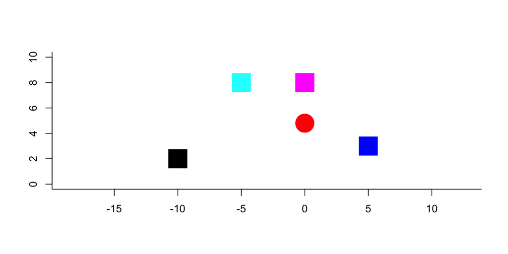

## IsoSource

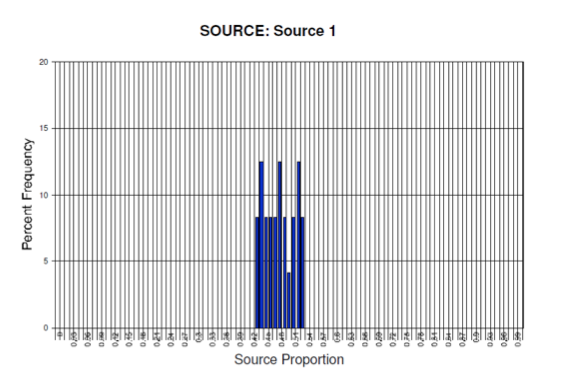

- took a brute force approach
- try every possible combination of sources in 1% increments
- accept if within some treshold of the mixture (consumer)
- reject if outside treshold

## SIAR / MixSIR / MixSIAR

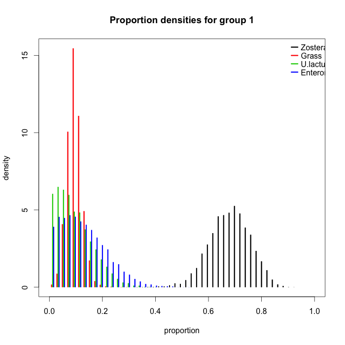

- uses Bayesian Inference to assign probabilities to the estimates
- frequency of occurrence, and proximity of estimate to the observed value increases the probability of a solution
- can also include prior information that weights the probability of a solution

## Comparing dietary proportions

- Proportion of terrestrial grass in the diet of Brent geese

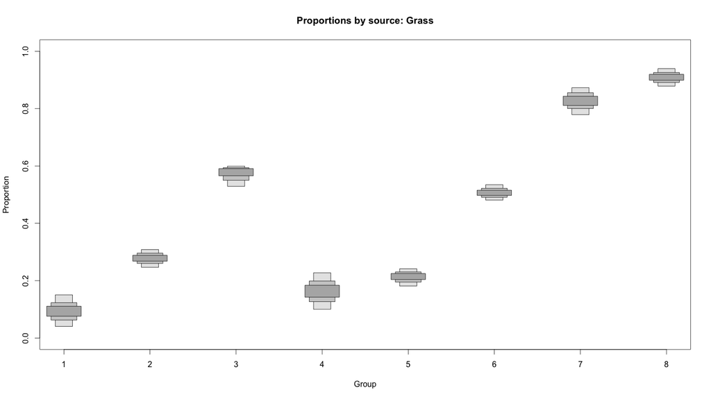

## Diet over time

- Diet can be linked to covariates such as time

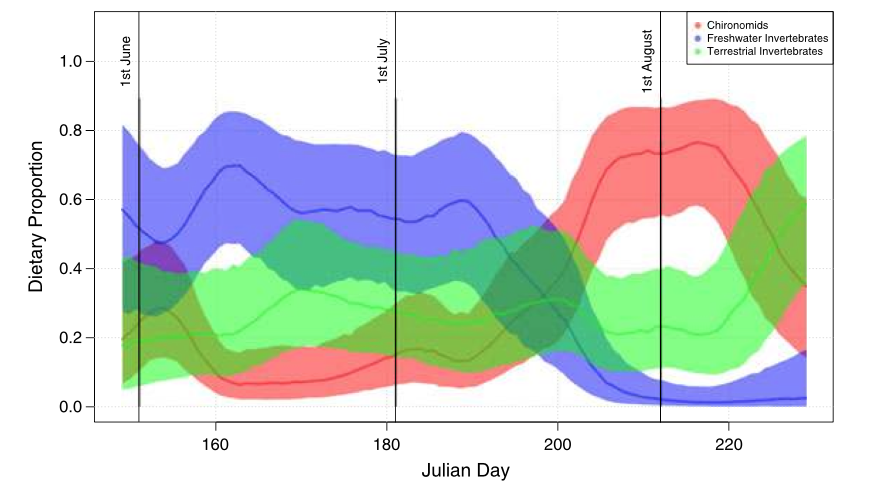

## Inference from d-space

- Isotopes are like naturally occurring PCA analyses
- They are two axes, behind which lie multiple biotic and physical factors
- d15N tells us a lot about trophic level for example
- d13C can tell us about marine Vs terrestrial among other scenopoetic factors
- Idea is that isotopic niche correlates in some way with ecological niche

## Specialists Vs generalists

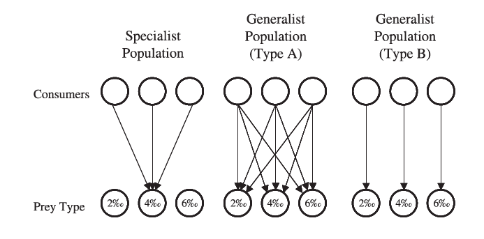

Bearhop, Adam, Waldron, Fuller & MacLeod. 2004. Determining trophic niche width: a novel approach using stable isotope analysis. J Anim Ecol.

## Drivers of niche width

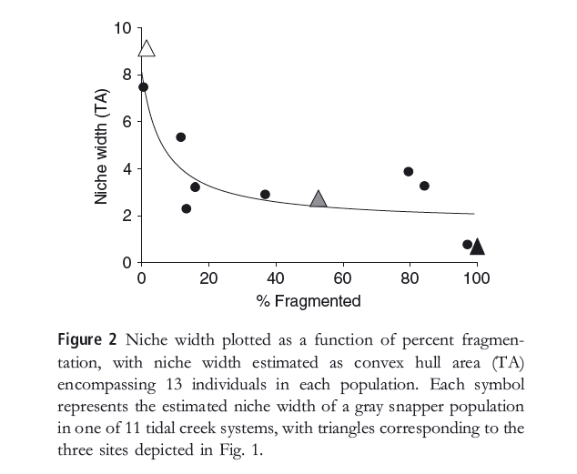

Layman et al. 2007. Niche width collapse in a resilient top predator following ecosystem fragmentation.

## Invasive species

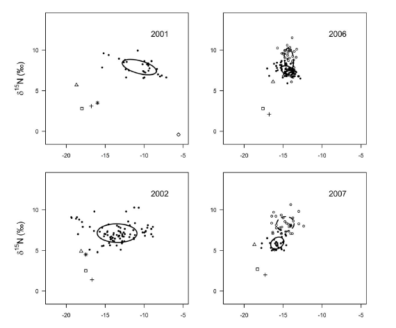

Jackson, M.C. et al. 2012. Population-Level Metrics of Trophic Structure Based on Stable Isotopes and Their Application to Invasion Ecology. PLoSONE.

## The question is key

- as with all science, your question will determine which analysis you require
- formulating a clear question at the start will inform your study design
- If you need to know what an animal is eating, then you require a SIMM
- if you want to compare the niche widths of populations then you probably want the ellipse functions in SIBER
- if you want to compare entire communities for niche structure, then you probably want the hull-based metrics in SIBER